# GWAS Report

## Overview

These are the GWAS results for job Test with 27.243 samples, run for the phenotype liver_fat .

## Methods

The association between liver_fat and each variant with a minor allele count $\ge$ 30 and an imputation quality metric $r^2 \ge$ 0.8 was tested using the linear regression model:

liver_fat ~ marker + PC1 + PC2 + PC3 + PC4 + PC5 + PC6 + PC7 + PC8 + PC9 + PC10 + PC11 + PC12 + PC13 + PC14 + PC15 + PC16 + PC17 + PC18 + PC19 + PC20 + array + sex + age

The association tests were performed using *plink2/2.00-alpha-2.3-20200124*, including a total of 14.308.111 markers (after filtering). Markers having a Hardy-Weinberg equilibrium exact test p-value below 1.0e-6 were filtered out.  
662 significant markers have been found. The genomic inflation factor was $\lambda =$ 1.0509461.

## GWAS parameters

The plink2 program was run with the following parameters:

- Minor allele count cutoff: 30
- Minor allele frequency cutoff: 0.00
- Maximum variance inflation factor: 50
- Sample missing call rate cutoff: 0.1
- Variant missing call rate cutoff: 0.1
- Minimum imputation quality: 0.8
- Maximum imputation quality: 2.0
- Hardy-Weinberg exact test p-value threshold: 1.0e-6

## Filtered samples and variants

The table displays the number of samples/variants that have been removed due to different filters:

- **SGENO**: Samples removed due to missing genotype. Cutoff: 0.1
- **VGENO**: Variants removed due to missing genotype. Cutoff: 0.1
- **VHWE**: Variants removed after Hardy-Weinberg exact test. P-value cutoff: 1.0e-6
- **VFREQ**: Variants removed due to allele frequency threshold(s). Cutoffs: mac = 30 ; maf = 0.00
- **VIMP**: Variants removed due to imputation quality filter (MACH-R2). Cutoff: 0.8 - 2.0

| CHROM | SGENO | % | VGENO | % | VHWE | % | VFREQ | % | VIMP | % |
| --- | --- | --- | --- | --- | --- | --- | --- | --- | --- | --- |
| 1 | 0 | 0 | 41841 | 0.57 | 1090 | 0.015 | 5803746 | 78 | 440400 | 5.9 |
| 2 | 0 | 0 | 36271 | 0.45 | 1217 | 0.015 | 6414783 | 79 | 455368 | 5.6 |
| 3 | 0 | 0 | 28337 | 0.42 | 545 | 0.0081 | 5264204 | 79 | 368369 | 5.5 |
| 4 | 0 | 0 | 32465 | 0.5 | 623 | 0.0095 | 5110979 | 78 | 370776 | 5.7 |
| 5 | 0 | 0 | 24848 | 0.41 | 818 | 0.013 | 4775049 | 79 | 328593 | 5.4 |
| 6 | 0 | 0 | 32304 | 0.56 | 1643 | 0.029 | 4444899 | 77 | 314492 | 5.5 |
| 7 | 0 | 0 | 29346 | 0.54 | 655 | 0.012 | 4225090 | 78 | 310371 | 5.7 |
| 8 | 0 | 0 | 21827 | 0.41 | 1209 | 0.023 | 4165788 | 79 | 290672 | 5.5 |
| 9 | 0 | 0 | 23404 | 0.58 | 554 | 0.014 | 3182382 | 78 | 232608 | 5.7 |
| 10 | 0 | 0 | 23708 | 0.52 | 1146 | 0.025 | 3554335 | 78 | 255731 | 5.6 |

[output cut: 13 more lines]

## GCTA-COJO results

The GCTA-COJO program was run using the following parameters:

- $p$-value: 5.0e-8
- window size: 5000 kB
- collinearity threshold ($R^2$): 0.9
- minor allele frequency cutoff (**A1_FREQ**): 0
- reference genome: FTD_rand

|  | ID | CHR | POS | OTHER | A1 | A1_FREQ | BETA | SE | P | genes |
| --- | --- | --- | --- | --- | --- | --- | --- | --- | --- | --- |
| 1 | rs8107974 | 19 | 19388500 | A | T | 0.0764 | 0.2869 | 0.0159 | 7.271e-73 | MIR640 |
| 2 | rs188247550 | 19 | 19396616 | C | T | 0.0145 | 0.2745 | 0.0366 | 6.203e-14 | MIR640 |
| 3 | rs429358 | 19 | 45411941 | T | C | 0.152 | -0.09136 | 0.0117 | 6.129e-15 | CD3EAP |
| 4 | rs738408 | 22 | 44324730 | C | T | 0.214 | 0.1914 | 0.0102 | 2.468e-78 | LOC101927499 |

## Table with corresponding original results

|  | ID | CHR | POS | OTHER | A1 | A1_FREQ | BETA | SE | P | genes |
| --- | --- | --- | --- | --- | --- | --- | --- | --- | --- | --- |
| 1 | rs8107974 | 19 | 19388500 | A | T | 0.0764 | 0.2825 | 0.0158 | 3.323e-71 | MIR640 |
| 2 | rs188247550 | 19 | 19396616 | C | T | 0.0145 | 0.2503 | 0.0365 | 7.393e-12 | MIR640 |
| 3 | rs429358 | 19 | 45411941 | T | C | 0.152 | -0.09136 | 0.0117 | 5.934e-15 | CD3EAP |
| 4 | rs738408 | 22 | 44324730 | C | T | 0.214 | 0.1914 | 0.0102 | 8.385e-79 | LOC101927499 |

## CLUMP results

The plink-clump program was run using the following parameters:

- primary $p$-value: 5e-8
- secondary $p$-value: 5e-6
- correlation threshold: 0.01
- window size: 5000 kb
- reference genome: FTD_rand

|  | ID | CHR | POS | OTHER | A1 | A1_FREQ | BETA | SE | P | genes |
| --- | --- | --- | --- | --- | --- | --- | --- | --- | --- | --- |
| 1 | rs188247550 | 19 | 19396616 | C | T | 0.0145 | 0.2503 | 0.0365 | 7.39e-12 | MIR640 |
| 2 | rs429358 | 19 | 45411941 | T | C | 0.152 | -0.09136 | 0.0117 | 5.93e-15 | CD3EAP |
| 3 | rs8107974 | 19 | 19388500 | A | T | 0.0764 | 0.2825 | 0.0158 | 3.32e-71 | MIR640 |
| 4 | rs738408 | 22 | 44324730 | C | T | 0.214 | 0.1914 | 0.0102 | 8.39e-79 | LOC101927499 |

## Comparison of the markers identified by COJO and by CLUMP

- The number of common markers indentified with the two methods is 4.
- This corresponds to 100 % of the clump markers and 100 % of the cojo markers.

## QQ-plot for $p$-values

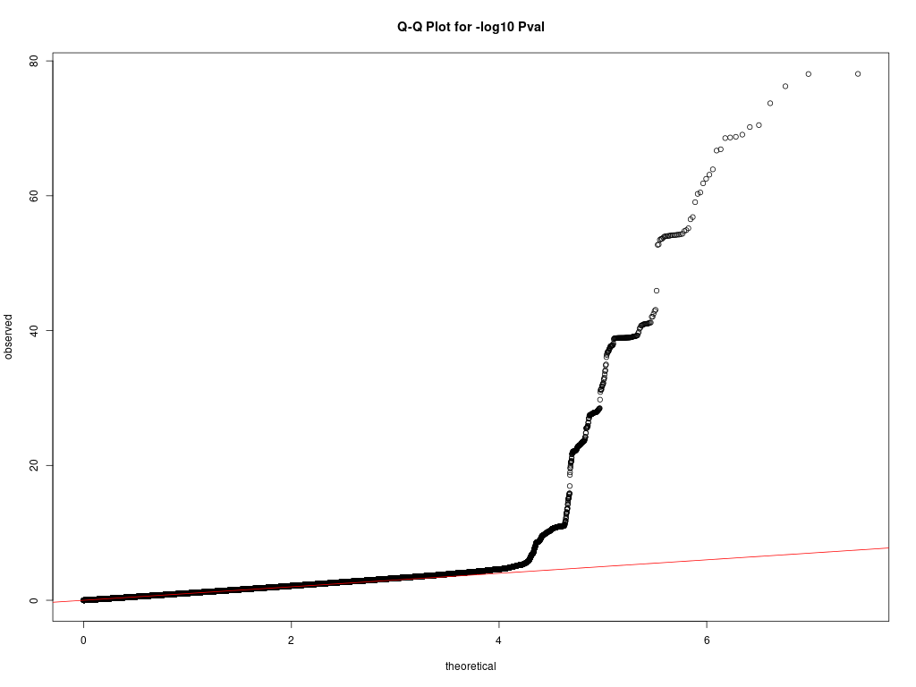

## Manhattan plot

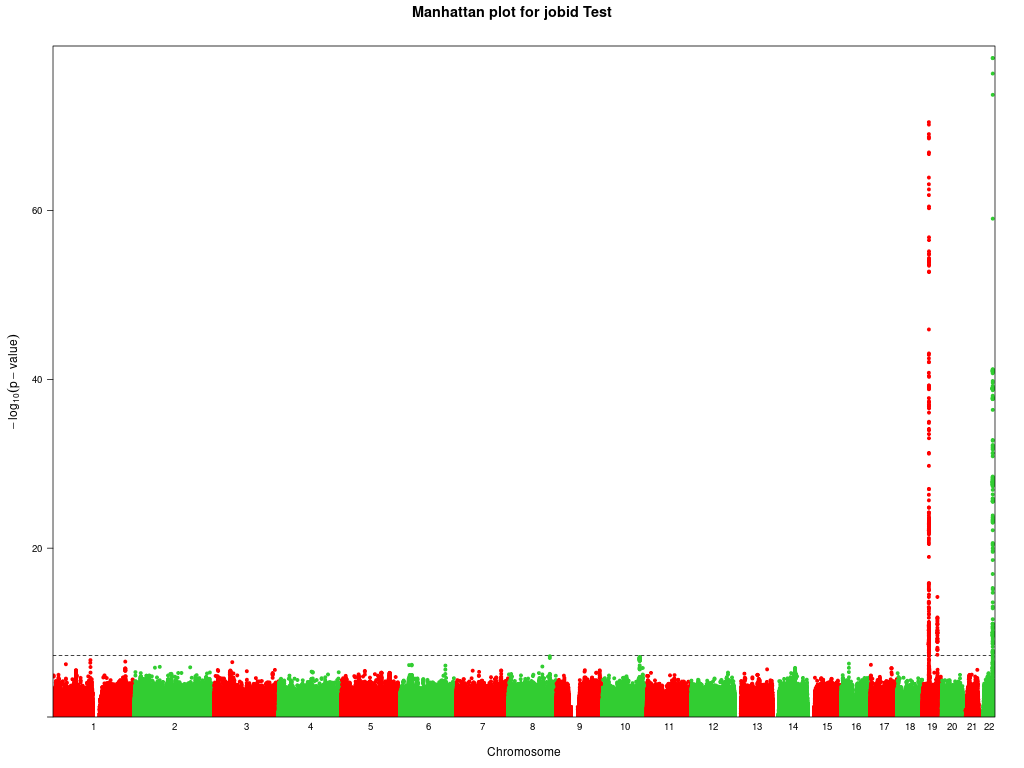

## SNP density plot

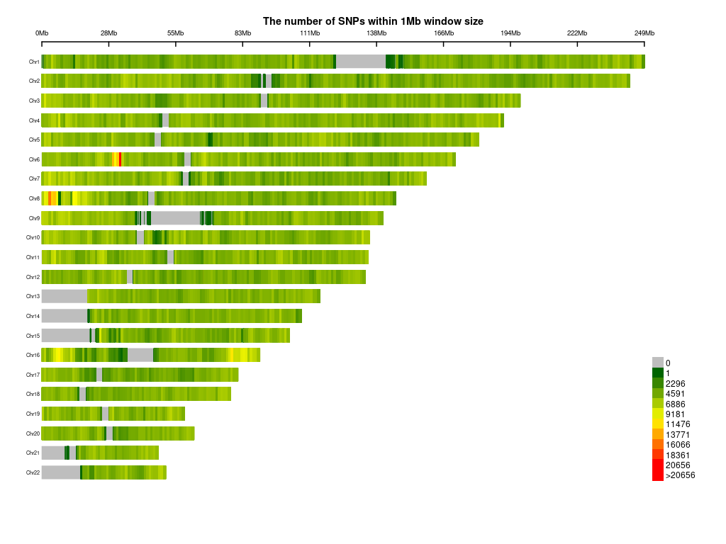

## Histogram of $\beta$ values

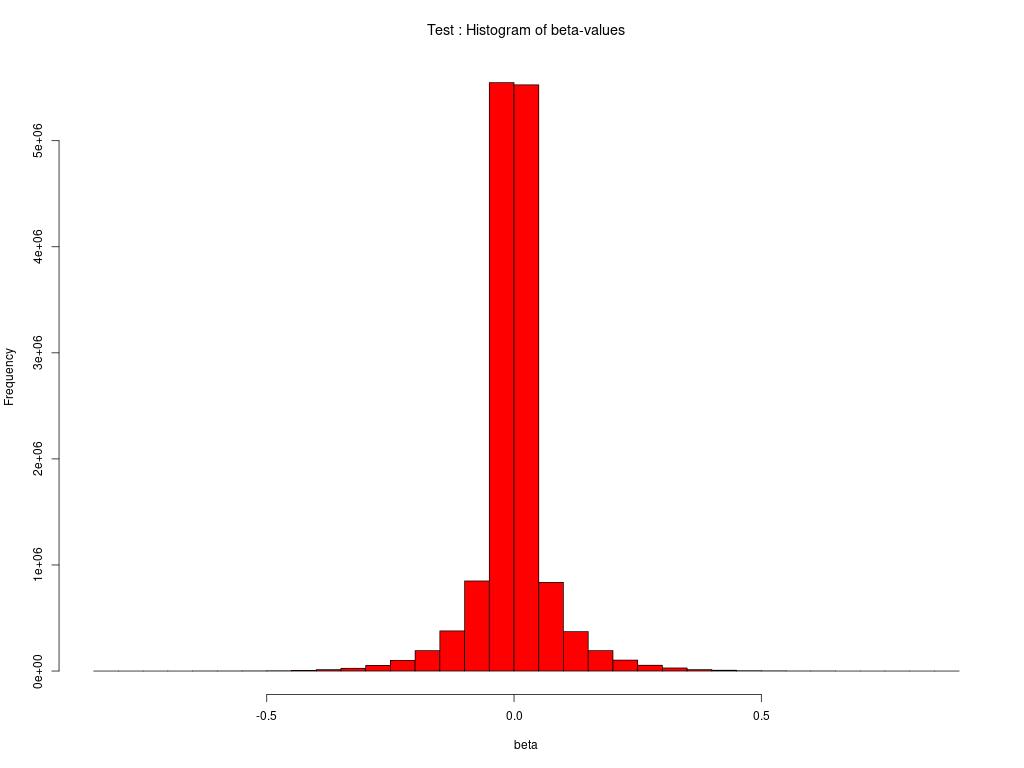

## Kernel density plot of $\beta$ values

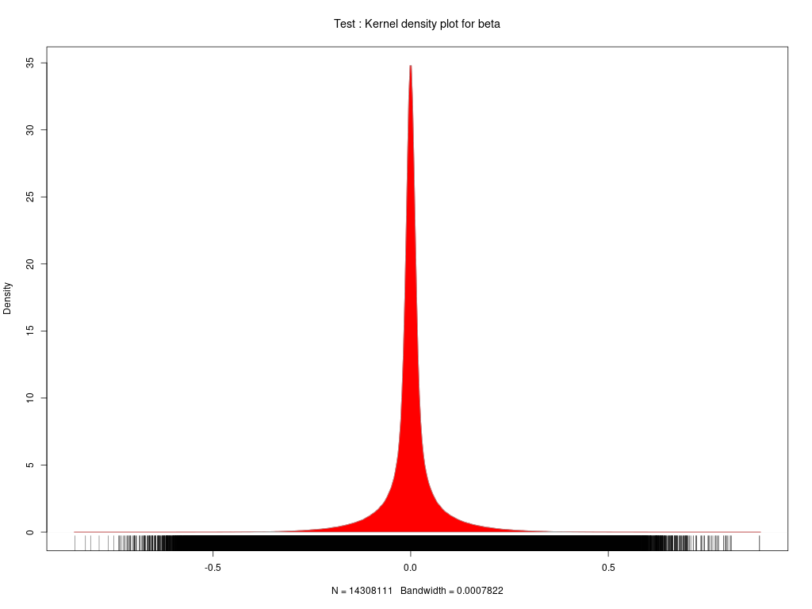

## Regression diagnostics

A regression was conducted using the linear model

liver_fat ~ PC1 + PC2 + PC3 + PC4 + PC5 + PC6 + PC7 + PC8 + PC9 + PC10 + PC11 + PC12 + PC13 + PC14 + PC15 + PC16 + PC17 + PC18 + PC19 + PC20 + array + sex + age

(Note that no marker genotype has been included). The dataframe used as regression input is stored in *Test_liver_fat_regression_frame.RData*, while the residuals are in *Test_liver_fat_regression_resid.RData*.

### Some metrics obtained using the linear regression model:

- **sigma** is the estimatimated standard deviation of the noise term
- **Fstat** is the value of the F-statistic
- **Rsquared** is coefficient of determination
- **Rsq.adj** is coefficient of determination adjusted for the number of predictors
- **AIC** is the Akaike information criterion (which estimates the quality of a gregession model, relative to others)

| sigma | Fstat | Rsquared | Rsq.adj | AIC |
| --- | --- | --- | --- | --- |
| 0.9795 | 50.94 | 0.04127 | 0.04046 | -1106 |

### Regression coefficients obtained with `lm()`:

|  | Estimate | Std. Error | t value | Pr(>\|t\|) |
| --- | --- | --- | --- | --- |
| (Intercept) | -0.645 | 0.0698 | -9.24 | 2.64e-20 |
| PC1 | -0.00515 | 0.00388 | -1.33 | 0.185 |
| PC2 | -0.00393 | 0.00402 | -0.978 | 0.328 |
| PC3 | -0.0142 | 0.00393 | -3.61 | 0.000306 |
| PC4 | -0.0164 | 0.00298 | -5.49 | 4e-08 |
| PC5 | 0.00165 | 0.00131 | 1.27 | 0.206 |
| PC6 | -0.0055 | 0.0037 | -1.48 | 0.138 |
| PC7 | -0.0179 | 0.00335 | -5.32 | 1.02e-07 |
| PC8 | 0.000926 | 0.00334 | 0.277 | 0.782 |
| PC9 | 0.00414 | 0.00158 | 2.61 | 0.00903 |

[output cut: 14 more lines]

## Variance inflation factors

Variance inflation factors (VIF) are calculated in order to discover multicollinearity. VIF can be obtained by regressing a single independent variable against all other independent variables. As a rule of thumb, no variance inflation factor should be bigger than 10. Otherwise, highly correlated variables should be removed from the model.

|  | vif | rating |
| --- | --- | --- |
| PC1 | 1.1128 | ok |
| PC2 | 1.0381 | ok |
| PC3 | 1.0928 | ok |
| PC4 | 2.1 | ok |
| PC5 | 2.0373 | ok |
| PC6 | 1.0806 | ok |
| PC7 | 1.1084 | ok |
| PC8 | 1.289 | ok |
| PC9 | 1.1519 | ok |
| PC10 | 1.5869 | ok |

[output cut: 13 more lines]

### Histogram for the magnitudes of the residuals

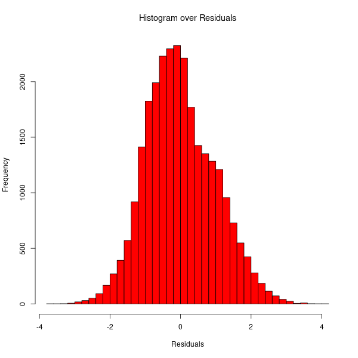

### Normal Q-Q plot of the residuals

This plot shows if residuals are normally distributed. It is desirable that the points displaying the residuals are located close to the straight line.

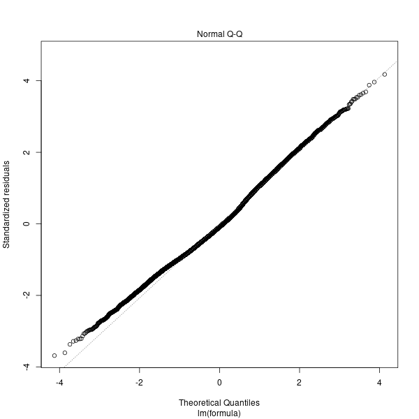

## Technical information

- GWAS **workfolder** /castor/project/proj/GWAS_TEST/Test
- **Parameter file**: /castor/project/proj/GWAS_TEST/Test/Test_gwas_params.txt